# Explore timetables data

Adam Bricknell, November 2021

```r
knitr::opts_chunk$set(echo = TRUE, warning = FALSE, message = FALSE)
library(dplyr )
library(purrr)
library(data.table)
```

```r
library(ggplot2)
```

## Isle of Wight timetables

The XML files for the Isle of Wight buses have been extracted into 8 tables. We explore them and how they link together here. We also attempt to link them to AVL.

```r
load("full_isle_of_wight.RData")

print(map(full_isle_of_wight, dim))
```

```
## $stop_points
## [1] 2504    5
##
## $all_route_sections_df
## [1] 70856     9
##
## $routes
## [1] 105   2
##
## $journey_pattern_sections
## [1] 17058    11
##
## $service_details
## [1] 48 11
##
## $standard_service
## [1] 367   6
##
## $operators
## [1] 30 17
##
## $vehicle_journeys_and_departure_times
## [1] 2230   23
```

## Stop points

Gives you ID code, name and lat/long of bus stops. There are 981 bus stops on the Isle of Wight

```r
head(full_isle_of_wight$stop_points)
```

```
##   StopPointRef            CommonName Location.Longitude Location.Latitude
## 1 23000002001A   Newport Bus Station       -1.294673593      50.698545671
## 2 230000008000              Towngate       -1.297045187      50.701869354
## 3 230000008090             Hunnyhill       -1.298316781      50.704907595
## 4 230000008270 Isle of Wight College       -1.300785414      50.707458398
## 5 230000008410    St Mary's Hospital       -1.302907370      50.710483695
## 6 230000009610       Lonsdale Avenue       -1.304575787      50.716419918
##                  file_source
## 1 Vectis 26 09 2021_SER1.xml
## 2 Vectis 26 09 2021_SER1.xml
## 3 Vectis 26 09 2021_SER1.xml
## 4 Vectis 26 09 2021_SER1.xml
## 5 Vectis 26 09 2021_SER1.xml
## 6 Vectis 26 09 2021_SER1.xml
```

## Route sections

Individual ‘links’, or line segments, for each route. May enable plotting of the route.

routelink = section of route (line segment). Links to ‘RouteLinkRef’ in journey_pattern_sections table

```r
print(unique(full_isle_of_wight$all_route_sections_df$route_section_id))
```

```
## [1] "RS1" "RS2" "RS3" "RS4" "RS5" "RS6" "RS7" "RS8" "RS9"
```

```r
head(full_isle_of_wight$all_route_sections_df)
```

```
##                  file_source routelink link_id     latitude    longitude
## 1 Vectis 26 09 2021_SER1.xml       RL1     L57 -1.294645703 50.698547827
## 2 Vectis 26 09 2021_SER1.xml       RL1     L58 -1.294665201 50.698649570
## 3 Vectis 26 09 2021_SER1.xml       RL1     L59 -1.294665414 50.698654144
## 4 Vectis 26 09 2021_SER1.xml       RL1     L60 -1.294707291 50.698653354
## 5 Vectis 26 09 2021_SER1.xml       RL1     L61 -1.294895158 50.698639356
## 6 Vectis 26 09 2021_SER1.xml       RL1     L62 -1.295016873 50.698669502
##   route_section_id unique_routelink_section_id ServiceCode
## 1              RS1                     RL1_RS1        SER1
## 2              RS1                     RL1_RS1        SER1
## 3              RS1                     RL1_RS1        SER1
## 4              RS1                     RL1_RS1        SER1
## 5              RS1                     RL1_RS1        SER1
## 6              RS1                     RL1_RS1        SER1
##   unique_service_routelink_id
## 1                    SER1_RL1
## 2                    SER1_RL1
## 3                    SER1_RL1
## 4                    SER1_RL1
## 5                    SER1_RL1
## 6                    SER1_RL1
```

Below are routes for one service (everything from one XML file). Looks like there is some noise in the coordinates of routes: perhaps it uses old AVL data or maybe something was missed in the processing.

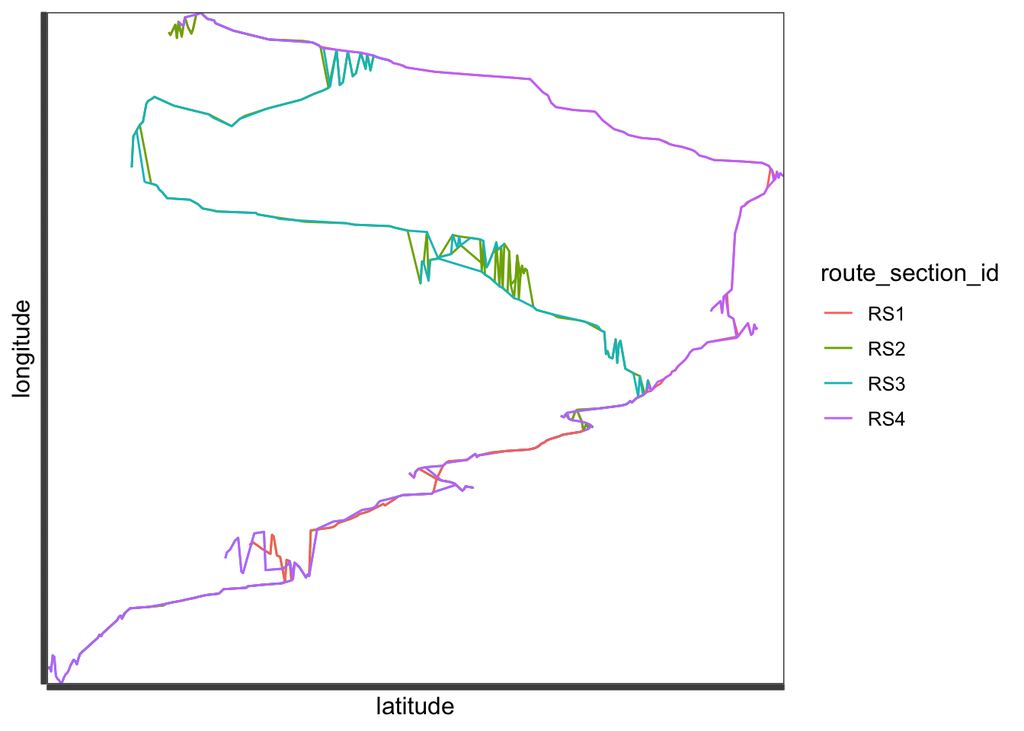

```r
full_isle_of_wight$all_route_sections_df %>%
  filter(file_source == 'Vectis 26 09 2021_SER1.xml') %>%
  ggplot(aes(x = latitude,
             y = longitude,
             group = routelink,
             color = route_section_id)) +
    geom_line() +
    ggthemes::theme_few() +
    theme(axis.text.y = element_blank(),
          axis.text.x = element_blank())
```

Below we plot every link on the Isle of Wight by service.

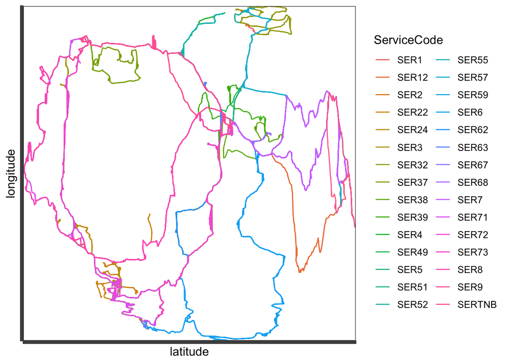

```r
full_isle_of_wight$all_route_sections_df %>%
  mutate(ServiceCode = as.factor(ServiceCode)) %>%
  ggplot(aes(x = latitude,
             y = longitude,
             group = unique_service_routelink_id,
             color = ServiceCode)) +
    geom_line() +
    ggthemes::theme_few() +
    theme(axis.text.y = element_blank(),
          axis.text.x = element_blank())
```

Zooming in on several routelinks for one service

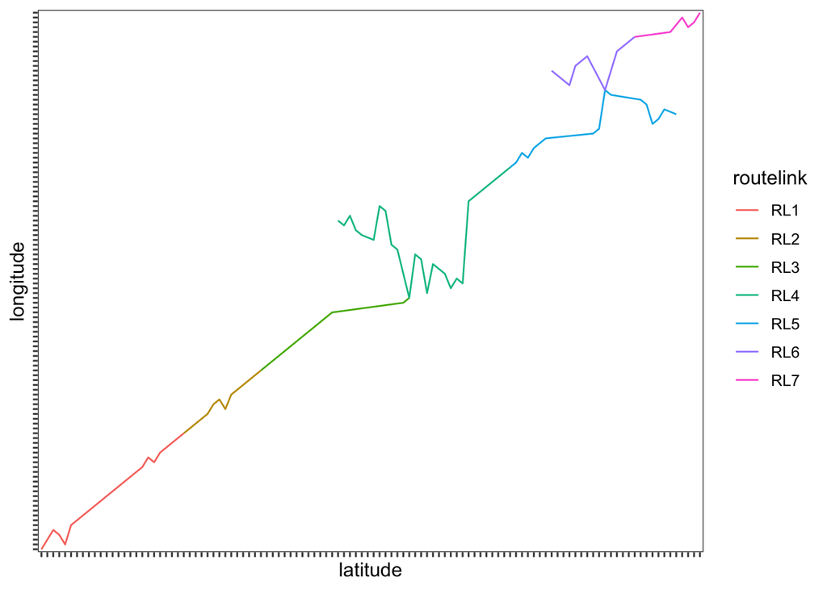

```r
full_isle_of_wight$all_route_sections_df %>%
  filter(routelink %in% c('RL1', 'RL2', 'RL3', 'RL4', 'RL5', 'RL6', 'RL7'),
         ServiceCode == 'SER1') %>%
ggplot(aes(x = latitude, y = longitude, group = routelink, color = routelink)) +
  geom_line() +
  ggthemes::theme_few() +
  theme(axis.text.y = element_blank(),
        axis.text.x = element_blank())
```

## Routes

Gives you unique route IDs

```r
head(full_isle_of_wight$routes)
```

```
##     id                 file_source
## 1  RT1  Vectis 26 09 2021_SER1.xml
## 2  RT2  Vectis 26 09 2021_SER1.xml
## 3 RT60  Vectis 26 09 2021_SER1.xml
## 4 RT61  Vectis 26 09 2021_SER1.xml
## 5 RT27 Vectis 26 09 2021_SER12.xml
## 6 RT88 Vectis 26 09 2021_SER12.xml
```

## Journey patterns

Gives each section of journey between bus stops (From.StopPointRef and To.StopPointRef : link to stop_points table) for each unique journey (journey_id)

RouteLinkRef = matches to ‘routelink’ in all_route_sections_df table (say, perhaps, if you wanted to plot the routes between each stop)

RunTime = estimated journey time for that section. PT2M = 2 minutes, etc

```r
head(full_isle_of_wight$journey_pattern_sections)
```

```
##   From.DynamicDestinationDisplay From.StopPointRef From.TimingStatus
## 1           Cowes via Four Cross      23000002001A               PTP
## 2                           <NA>      230000008000               OTH
## 3                           <NA>      230000008090               OTH
## 4                           <NA>      230000008270               OTH
## 5                           <NA>      230000008410               PTP
## 6                           <NA>      230000009610               OTH
##   To.DynamicDestinationDisplay To.StopPointRef To.TimingStatus RouteLinkRef
## 1            Cowes Carvel Lane    230000008000             OTH          RL1
## 2                         <NA>    230000008090             OTH          RL2
## 3                         <NA>    230000008270             OTH          RL3
## 4                         <NA>    230000008410             PTP          RL4
## 5                         <NA>    230000009610             OTH          RL5
## 6                         <NA>    230000008570             OTH          RL6
##   RunTime journey_id                file_source From.WaitTime
## 1    PT2M       JPS1 Vectis 26 09 2021_SER1.xml          <NA>
## 2    PT1M       JPS1 Vectis 26 09 2021_SER1.xml          <NA>
## 3    PT1M       JPS1 Vectis 26 09 2021_SER1.xml          <NA>
## 4    PT3M       JPS1 Vectis 26 09 2021_SER1.xml          <NA>
## 5    PT0S       JPS1 Vectis 26 09 2021_SER1.xml          <NA>
## 6    PT1M       JPS1 Vectis 26 09 2021_SER1.xml          <NA>
```

## Operators

Operator details for each service. Can join to Service Details with ServiceCode

```r
head(full_isle_of_wight$operators)
```

```
##   NationalOperatorCode OperatorCode OperatorShortName OperatorNameOnLicence
## 1                 SVCT         SVCT    SouthernVectis          GoSouthCoast
## 2                 SVCT         SVCT    SouthernVectis          GoSouthCoast
## 3                 SVCT         SVCT    SouthernVectis          GoSouthCoast
## 4                 SVCT         SVCT    SouthernVectis          GoSouthCoast
## 5                 SVCT         SVCT    SouthernVectis          GoSouthCoast
## 6                 SVCT         SVCT    SouthernVectis          GoSouthCoast
##      TradingName LicenceNumber LicenceClassification
## 1 SouthernVectis     PH1121126      standardNational
## 2 SouthernVectis     PH1121126      standardNational
## 3 SouthernVectis     PH1121126      standardNational
## 4 SouthernVectis     PH1121126      standardNational
## 5 SouthernVectis     PH1121126      standardNational
## 6 SouthernVectis     PH1121126      standardNational
##   EnquiryTelephoneNumber.TelNationalNumber
```

[output cut: 48 more lines]

## Service details

Operator details for each service

```r
head(full_isle_of_wight$service_details)
```

```
##       ServiceCode PrivateCode Lines.Line.LineName OperatingPeriod.StartDate
## ....1        SER1     SVAO001                   1                2021-09-26
## ...2        SER12     SVAO012                  12                2021-09-26
## ...3        SER12     SVAO012                  12                2021-09-26
## ...4         SER2     SVAO002                   2                2021-09-26
## ...5         SER2     SVAO002                   2                2021-09-26
## ...6        SER22     SVAO022                  22                2021-09-26
##       OperatingPeriod.EndDate RegisteredOperatorRef          Direction    start
## ....1              2021-12-23                    O4 inboundAndOutbound  Newport
## ...2               2021-12-23                    O4 inboundAndOutbound  Newport
## ...3               2021-12-23                    O4 inboundAndOutbound  Newport
## ...4               2021-12-23                    O4 inboundAndOutbound  Newport
## ...5               2021-12-23                    O4 inboundAndOutbound  Newport
## ...6               2021-12-23                    O4 inboundAndOutbound Knighton
##            end       vias                 file_source
## ....1    Cowes             Vectis 26 09 2021_SER1.xml
## ...2  Alum Bay Freshwater Vectis 26 09 2021_SER12.xml
## ...3  Alum Bay    Totland Vectis 26 09 2021_SER12.xml
## ...4      Ryde   Shanklin  Vectis 26 09 2021_SER2.xml
## ...5      Ryde    Sandown  Vectis 26 09 2021_SER2.xml
## ...6  Shanklin  Newchurch Vectis 26 09 2021_SER22.xml
```

## Standard service

Shows ultimate destination at each link in the service. And whether inbound or outbound.

```r
head(full_isle_of_wight$standard_service)
```

```
##   DestinationDisplay Direction                             Description RouteRef
## 1  Cowes Carvel Lane  outbound Newport Bus Station - Cowes Carvel Lane      RT1
## 2  Cowes Carvel Lane  outbound Newport Bus Station - Cowes Carvel Lane      RT1
## 3  Cowes Carvel Lane  outbound Newport Bus Station - Cowes Carvel Lane      RT1
## 4  Cowes Carvel Lane  outbound Newport Bus Station - Cowes Carvel Lane      RT1
## 5  Cowes Carvel Lane  outbound Newport Bus Station - Cowes Carvel Lane      RT1
## 6  Cowes Carvel Lane  outbound Newport Bus Station - Cowes Carvel Lane      RT1
##   JourneyPatternSectionRefs                file_source
## 1                      JPS1 Vectis 26 09 2021_SER1.xml
## 2                      JPS2 Vectis 26 09 2021_SER1.xml
## 3                      JPS3 Vectis 26 09 2021_SER1.xml
## 4                      JPS4 Vectis 26 09 2021_SER1.xml
## 5                      JPS5 Vectis 26 09 2021_SER1.xml
## 6                      JPS6 Vectis 26 09 2021_SER1.xml
```

## Vehicle journey and departure times

There last 10 columns are sparsely populated: there aren’t included for many routes

```r
head(full_isle_of_wight$vehicle_journeys_and_departure_times)
```

```
##     PrivateCode Operational.VehicleType.VehicleTypeCode
## 1 001MFSVCT:O:1                                    LFDD
## 2 001MFSVCT:O:2                                    LFDD
## 3 001MFSVCT:O:3                                    LFDD
## 4 001MFSVCT:O:4                                    LFDD
## 5 001MFSVCT:O:5                                    LFDD
## 6 001MFSVCT:O:6                                    LFDD
##   Operational.VehicleType.Description
## 1                         Double deck
## 2                         Double deck
## 3                         Double deck
## 4                         Double deck
## 5                         Double deck
## 6                         Double deck
##   Operational.TicketMachine.TicketMachineServiceCode
```

[output cut: 90 more lines]

Below we see the distribution of departure times.

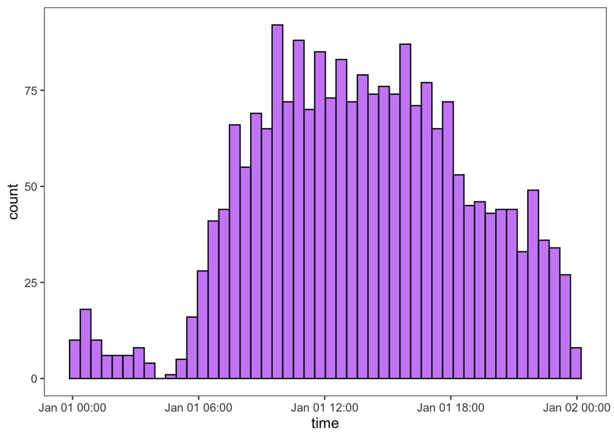

```r
hist <- lubridate::parse_date_time(full_isle_of_wight$vehicle_journeys_and_departure_times$DepartureTime, orders = '%H:%M:%S') %>%
  as.data.frame() %>%
  magrittr::set_colnames('time') %>%
  ggplot(aes(x = time, alpha = 0.6)) +
    geom_histogram(fill='purple',colour = 'black', bins = 48) +
    ggthemes::theme_few() +
    theme(legend.position = 'none')

hist
```

## Does JourneyPatternRef link to journey_id?

```r
journey_ids <- unique(full_isle_of_wight$journey_pattern_sections$journey_id) %>% substring(4)
pattern_refs <- unique(full_isle_of_wight$vehicle_journeys_and_departure_times$JourneyPatternRef) %>% substring(3)

print(pattern_refs %in% journey_ids)
```

```
##  [1] TRUE TRUE TRUE TRUE TRUE TRUE TRUE TRUE TRUE TRUE TRUE TRUE TRUE TRUE TRUE
## [16] TRUE TRUE TRUE TRUE TRUE TRUE TRUE TRUE TRUE TRUE TRUE TRUE TRUE TRUE TRUE
## [31] TRUE TRUE TRUE TRUE TRUE TRUE TRUE TRUE TRUE TRUE TRUE TRUE TRUE TRUE TRUE
## [46] TRUE TRUE TRUE TRUE TRUE TRUE TRUE TRUE TRUE TRUE TRUE TRUE TRUE TRUE TRUE
## [61] TRUE TRUE TRUE TRUE TRUE TRUE TRUE TRUE TRUE TRUE TRUE TRUE TRUE TRUE TRUE
```

```r
print(journey_ids %in% pattern_refs)
```

```
##   [1]  TRUE  TRUE  TRUE  TRUE  TRUE  TRUE  TRUE  TRUE  TRUE  TRUE  TRUE  TRUE
##  [13]  TRUE  TRUE  TRUE  TRUE  TRUE  TRUE  TRUE  TRUE  TRUE  TRUE  TRUE  TRUE
##  [25]  TRUE  TRUE  TRUE  TRUE  TRUE  TRUE  TRUE  TRUE  TRUE  TRUE  TRUE  TRUE
##  [37]  TRUE FALSE FALSE  TRUE  TRUE  TRUE  TRUE  TRUE  TRUE  TRUE  TRUE  TRUE
##  [49]  TRUE  TRUE  TRUE  TRUE  TRUE  TRUE  TRUE  TRUE  TRUE  TRUE  TRUE  TRUE
##  [61]  TRUE  TRUE  TRUE  TRUE  TRUE  TRUE  TRUE  TRUE  TRUE  TRUE FALSE FALSE
##  [73] FALSE FALSE FALSE FALSE FALSE FALSE FALSE FALSE  TRUE  TRUE  TRUE  TRUE
##  [85]  TRUE  TRUE  TRUE FALSE FALSE FALSE FALSE FALSE FALSE FALSE FALSE FALSE
##  [97] FALSE FALSE FALSE FALSE FALSE FALSE FALSE FALSE FALSE FALSE FALSE FALSE
## [109] FALSE FALSE FALSE FALSE FALSE FALSE FALSE FALSE FALSE FALSE FALSE FALSE
## [121] FALSE FALSE FALSE FALSE FALSE FALSE FALSE FALSE FALSE FALSE FALSE FALSE
## [133] FALSE FALSE FALSE FALSE FALSE FALSE FALSE FALSE FALSE FALSE FALSE FALSE
## [145] FALSE FALSE FALSE FALSE FALSE FALSE FALSE FALSE FALSE FALSE FALSE FALSE
## [157] FALSE FALSE FALSE FALSE FALSE FALSE FALSE FALSE FALSE FALSE FALSE FALSE
## [169] FALSE FALSE FALSE FALSE FALSE FALSE FALSE FALSE FALSE FALSE FALSE FALSE
```

[output cut: 16 more lines]